# CSCI 385 - Third Deliverable

Jamie Van Winckel

12/14/2020

# Introduction

Is it possible to predict the voter turnout percentage of a state in a presidential election based on the state’s voter ID law?

This question matters because if it is possible to predict voter turnout based on voter ID law then it is possible to increase voter turnout by changing the voter ID law. Such a low amount of Americans vote every year, and after this 2020 election we saw a huge increase in voters. If there is a way to get as many Americans that voted this year to vote every year, it could have a real impact to get everyone’s voices heard.

If voter turnout is related to different voter laws, then my prediction will be a success. However, if there is no relation or not a strong enough relation then my prediction will be false.

There are five different voter ID laws in the United States. They come in four categories: photo and non-photo, and strict and non-strict.

- Photo ID requirements:
  - States with photo ID requirements mandate voters to bring a state-issued driver’s license, non-driver ID or voter card, US passport, or a military, tribal, student, or state employee card to the polls in order to vote.
- Non-Photo ID requirements:
  - Non-photo ID states allow voters to bring official government mailings or other recent documents that bear the voter’s name and address, like a utility or rent bill, pay-stub, or bank statement.
- Non-Strict requirements:
  - Non-strict states allow voters without the required documentation to cast a sworn affidavit or reasonable impediment declaration or to have a poll worker vouch for them in order to vote
- Strict requirements:
  - Strict states require voters to cast a provisional ballot and later provide additional proof of residency to their election officials in order for their vote to count.

The five different types of voter ID laws are listed below:

- No ID requirement
- Non-strict non-photo ID
- Non-strict photo ID
- Strict non-photo ID
- Strict photo ID These five types will be used to predict if voter turnout is affected by the voter laws of the state.

## First Two Deliverables Summary

My first deliverable focused on a large data set that had an abundance of demographic information for nearly every county in the United States (except for Alaska). This dataset was difficult to make visualizations with because all of the data was percentages and there was no categorical data.

## Web Scraping

I web scraped a website to get information on the population of people over 18 per state. This is also known as the Voting AGe Population. This is not the number of eligible voters because there are numerous reasons why people cannot vote.

```r
voterInfo <- read_html("https://www.federalregister.gov/documents/2019/10/04/2019-21663/estimates-of-the-voting-age-population-for-2018")

voterInfo <- setNames(data.frame(cbind(
  html_text(html_nodes(voterInfo, ".border-right-single")),
  html_text(html_nodes(voterInfo, ".right"))
)), c("StateName", "PopulationOver18"))

voterInfo$PopulationOver18 <- as.numeric(gsub(",","",voterInfo$PopulationOver18))
voterInfo <- voterInfo[-1,]
voterInfo <- as_tibble(voterInfo)
head(voterInfo)
```

```
## # A tibble: 6 x 2
##   StateName     PopulationOver18
##   <chr>                    <dbl>
## 1 United States        253768092
## 2 Alabama                3798031
## 3 Alaska                  553622
## 4 Arizona                5528989
## 5 Arkansas               2310645
## 6 California            30567090
```

# Data Summary

This table has information per state about voting and election information. This is arguably one of the most important tables in this project. This table is the reason why I chose to investigate the correlation between voter ID laws and voter turnout per state.

```r
head(stateInfo)
```

```
##   State  StateName StateAbbr ElectoralVotes AllowsPartyRegistration VoterIDLaw
## 1     1    Alabama        AL              9                   FALSE          3
## 2     2     Alaska        AK              3                    TRUE          2
## 3     4    Arizona        AZ             11                   FALSE          4
## 4     5   Arkansas        AR              6                   FALSE          2
## 5     6 California        CA             55                    TRUE          1
## 6     8   Colorado        CO              9                    TRUE          2
##         VoterIDLawVerbose ClosedPrimary
## 1     Non-strict photo ID         FALSE
## 2 Non-strict non-photo ID         FALSE
## 3     Strict non-photo ID         FALSE
## 4 Non-strict non-photo ID         FALSE
## 5       No ID requirement         FALSE
## 6 Non-strict non-photo ID         FALSE
```

This table shows the population over 18 per state.

```r
head(voterInfo)
```

```
## # A tibble: 6 x 2
##   StateName     PopulationOver18
##   <chr>                    <dbl>
## 1 United States        253768092
## 2 Alabama                3798031
## 3 Alaska                  553622
## 4 Arizona                5528989
## 5 Arkansas               2310645
## 6 California            30567090
```

The next four tables have information per state about the eligible voting population and the turnout per presidential election from 2008 to 2020. These tables have been very helpful, they have allowed me to test my model to see if I can accurately guess what a state’s voter turnout will be one year based on voter information from the previous year.

```r
head(voterTurnout2008)
```

```
##           State VEP.Total.Ballots.Counted VEP.Highest.Office VAP.Highest.Office
## 1 United States                    62.20%             61.60%             56.90%
## 2       Alabama                    61.00%             60.80%             58.40%
## 3        Alaska                    68.30%             68.00%             64.30%
## 4       Arizona                    57.40%             56.70%             49.10%
## 5      Arkansas                    52.90%             52.50%             50.00%
## 6    California                    61.70%             60.90%             49.50%
##   Total.Ballots.Counted Highest.Office Voting.Eligible.Population..VEP.
## 1             132609063      131304731                        213313508
## 2               2105622        2099819                          3454510
## 3                327341         326197                           479429
## 4               2320851        2293475                          4046075
## 5               1095958        1086617                          2071563
## 6              13743177       13561900                         22261504
##   Voting.Age.Population..VAP. Percent.Non.citizen
## 1                   230872030               8.40%
## 2                     3595708               2.20%
## 3                      507645               3.70%
## 4                     4673718              11.60%
## 5                     2174846               2.90%
## 6                    27411094              17.90%
```

```r
head(voterTurnout2012)
```

```
##           State VEP.Total.Ballots.Counted2012 VEP.Highest.Office2012
## 1 United States                        58.60%                 58.00%
## 2       Alabama                        58.61%                 58.60%
## 3        Alaska                        58.90%                 58.70%
## 4       Arizona                        53.00%                 52.60%
## 5      Arkansas                        51.10%                 50.70%
## 6    California                        55.70%                 55.10%
##   VAP.Highest.Office2012 Total.Ballots.Counted2012 Highest.Office2012
## 1                 53.60%                 130292355          129070906
## 2                 56.00%                   2074338            2074338
## 3                 55.30%                    301694             300495
## 4                 46.50%                   2323579            2306559
## 5                 47.70%                   1078548            1069468
## 6                 45.10%                  13202158           13038547
##   Voting.Eligible.Population.VEP2012 Voting.Age.Population.VAP2012
## 1                          222474111                     240957993
## 2                            3539217                       3707440
## 3                             511792                        543763
## 4                            4387900                       4959270
## 5                            2109847                       2242740
## 6                           23681837                      28913129
##   Percent.Non.citizen State.Abv
## 1               8.40%
## 2               2.60%        AL
## 3               3.80%        AK
## 4               9.90%        AZ
## 5               3.50%        AR
## 6              17.40%        CA
```

```r
head(voterTurnout2016)
```

```
##           State VEP.Total.Ballots.Counted2016 VEP.Highest.Office2016
## 1 United States                        60.10%                 59.20%
## 2       Alabama                        59.10%                 58.80%
## 3        Alaska                        61.50%                 61.00%
## 4       Arizona                        56.10%                 54.90%
## 5      Arkansas                        53.20%                 52.80%
## 6    California                        58.20%                 56.50%
##   VAP.Highest.Office2016 Total.Ballots.Counted2016 Highest.Office2016
## 1                 54.70%                 138846571          136753936
## 2                 56.30%                   2134061            2123372
## 3                 57.40%                    321271             318608
## 4                 48.90%                   2661497            2604657
## 5                 49.40%                   1137772            1130635
## 6                 47.00%                  14610509           14181595
##   Voting.Eligible.Population.VEP2016 Voting.Age.Population.VAP2016
## 1                          230931921                     250055734
## 2                            3609447                       3770142
## 3                             522679                        555367
## 4                            4740310                       5331034
## 5                            2140097                       2286625
## 6                           25104844                      30201571
##   Percent.Non.citizen State.Abv
## 1               8.30%
## 2               2.50%        AL
## 3               4.10%        AK
## 4               9.40%        AZ
## 5               3.80%        AR
## 6              16.40%        CA
```

```r
head(voterTurnout2020)
```

```
##           State Total.Ballots.Counted..Estimate.
## 1 United States                        159215664
## 2       Alabama                          2325000
## 3        Alaska                           360684
## 4       Arizona                          3420565
## 5      Arkansas                          1222924
## 6    California                         17400000
##   Vote.for.Highest.Office..President. VEP.Turnout.Rate
## 1                                  NA           66.50%
## 2                             2323282           63.10%
## 3                              358802           68.60%
## 4                             3385294           65.90%
## 5                             1217036           56.00%
## 6                                  NA           67.00%
##   Voting.Eligible.Population..VEP. Voting.Age.Population..VAP.
## 1                        239247182                   257605088
## 2                          3683055                     3837540
## 3                           525568                      551117
## 4                          5189000                     5798473
## 5                          2182375                     2331171
## 6                         25962648                    30783255
##   Percent.Non.citizen State.Abv
## 1               7.80%
## 2               2.30%        AL
## 3               3.40%        AK
## 4               8.90%        AZ
## 5               3.60%        AR
## 6              15.00%        CA
```

Below I am making a tibble that has information about the state’s voter ID laws, voter turnout information from 2012 and 2016 (so that I can make a prediction of voter turnout in 2016 based on 2012 turnout), and a new column of voter turnout in 2016 per state (I will use this column to compare with my prediction model).

The four tables each contain information per state about the voting turnout that year, amount of eligible people, amount of people of voting age, and more. In the second deliverable I did not realize I had 6 NA’s in the data that went into the calculation of the voterTurnout2016 variable. No there are no NA’s, I went to the state government of each NA and documented the correct number of the missing value.

```r
voterTurnout2016 <- voterTurnout2016 %>%
  mutate(turnoutPercent2016 = (Total.Ballots.Counted2016 / Voting.Eligible.Population.VEP2016) * 100)
turnout1216 <- inner_join(voterTurnout2016, voterTurnout2012, by = c("State" = "State"))
turnout1216 <- inner_join(stateInfo, turnout1216, by = c("StateName" = "State"))
head(turnout1216)
```

```
##   State  StateName StateAbbr ElectoralVotes AllowsPartyRegistration VoterIDLaw
## 1     1    Alabama        AL              9                   FALSE          3
## 2     2     Alaska        AK              3                    TRUE          2
## 3     4    Arizona        AZ             11                   FALSE          4
## 4     5   Arkansas        AR              6                   FALSE          2
## 5     6 California        CA             55                    TRUE          1
## 6     8   Colorado        CO              9                    TRUE          2
##         VoterIDLawVerbose ClosedPrimary VEP.Total.Ballots.Counted2016
## 1     Non-strict photo ID         FALSE                        59.10%
## 2 Non-strict non-photo ID         FALSE                        61.50%
## 3     Strict non-photo ID         FALSE                        56.10%
## 4 Non-strict non-photo ID         FALSE                        53.20%
## 5       No ID requirement         FALSE                        58.20%
## 6 Non-strict non-photo ID         FALSE                        71.90%
##   VEP.Highest.Office2016 VAP.Highest.Office2016 Total.Ballots.Counted2016
```

[output cut: 48 more lines]

```r
stateVoterTurnout2008 <- inner_join(stateInfo, voterTurnout2008, by = c("StateName" = "State"))
stateVoterTurnout2012 <- inner_join(stateInfo, voterTurnout2012, by = c("StateName" = "State"))
head(stateVoterTurnout2012)
```

```
##   State  StateName StateAbbr ElectoralVotes AllowsPartyRegistration VoterIDLaw
## 1     1    Alabama        AL              9                   FALSE          3
## 2     2     Alaska        AK              3                    TRUE          2
## 3     4    Arizona        AZ             11                   FALSE          4
## 4     5   Arkansas        AR              6                   FALSE          2
## 5     6 California        CA             55                    TRUE          1
## 6     8   Colorado        CO              9                    TRUE          2
##         VoterIDLawVerbose ClosedPrimary VEP.Total.Ballots.Counted2012
## 1     Non-strict photo ID         FALSE                        58.61%
## 2 Non-strict non-photo ID         FALSE                        58.90%
## 3     Strict non-photo ID         FALSE                        53.00%
## 4 Non-strict non-photo ID         FALSE                        51.10%
## 5       No ID requirement         FALSE                        55.70%
## 6 Non-strict non-photo ID         FALSE                        70.60%
##   VEP.Highest.Office2012 VAP.Highest.Office2012 Total.Ballots.Counted2012
```

[output cut: 20 more lines]

```r
stateVoterTurnout2016 <- inner_join(stateInfo, voterTurnout2016, by = c("StateName" = "State"))
head(stateVoterTurnout2016)
```

```
##   State  StateName StateAbbr ElectoralVotes AllowsPartyRegistration VoterIDLaw
## 1     1    Alabama        AL              9                   FALSE          3
## 2     2     Alaska        AK              3                    TRUE          2
## 3     4    Arizona        AZ             11                   FALSE          4
## 4     5   Arkansas        AR              6                   FALSE          2
## 5     6 California        CA             55                    TRUE          1
## 6     8   Colorado        CO              9                    TRUE          2
##         VoterIDLawVerbose ClosedPrimary VEP.Total.Ballots.Counted2016
## 1     Non-strict photo ID         FALSE                        59.10%
## 2 Non-strict non-photo ID         FALSE                        61.50%
## 3     Strict non-photo ID         FALSE                        56.10%
## 4 Non-strict non-photo ID         FALSE                        53.20%
## 5       No ID requirement         FALSE                        58.20%
## 6 Non-strict non-photo ID         FALSE                        71.90%
##   VEP.Highest.Office2016 VAP.Highest.Office2016 Total.Ballots.Counted2016
```

[output cut: 27 more lines]

```r
stateVoterTurnout2020 <- inner_join(stateInfo, voterTurnout2020, by = c("StateName" = "State"))
```

# Data Exploration

This graph is a scatterplot of the number of electoral votes of a given state and their voter turnout percentage in 2016. I think it is interesting that the only states that have a voter turnout rate higher than 70% have 10 or fewer electoral votes. This could possibly be because the more elecotral votes a state has the more people they have, which could lead to lower voter turnout statistically speaking.

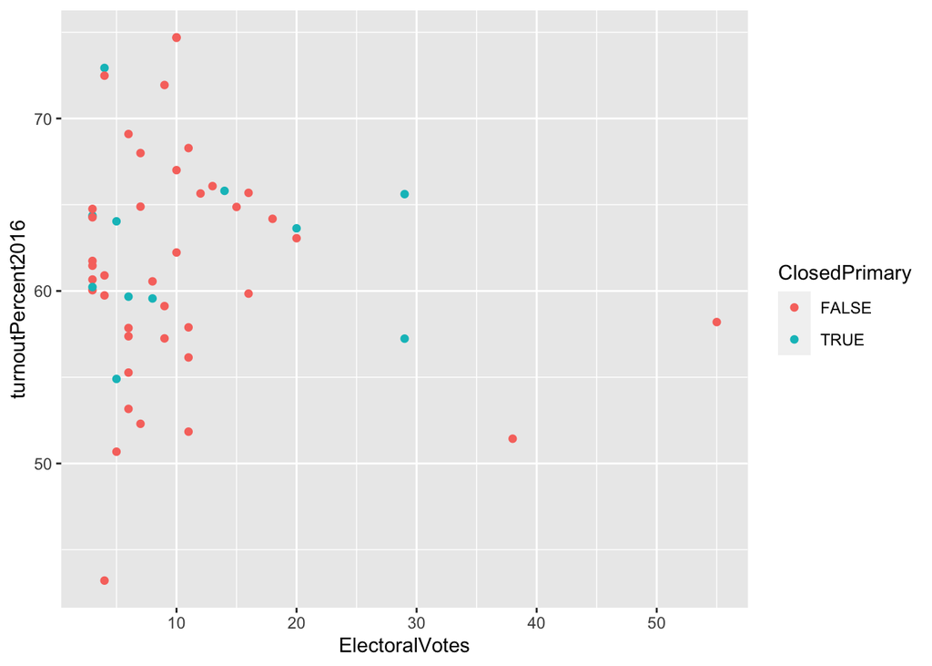

```r
ggplot(stateVoterTurnout2016, mapping = aes(x = ElectoralVotes, y = turnoutPercent2016, color = ClosedPrimary)) +
  geom_point(alpha = 1)
```

Here I combined the stateInfo and voterInfo tables so that I could look at the variable PopulationOver18 with the stateInfo table in the next graph.

```r
stateVoterInfo <- inner_join(stateInfo, voterInfo, by = c("StateName" = "StateName"))
head(stateVoterInfo)
```

```
##   State  StateName StateAbbr ElectoralVotes AllowsPartyRegistration VoterIDLaw
## 1     1    Alabama        AL              9                   FALSE          3
## 2     2     Alaska        AK              3                    TRUE          2
## 3     4    Arizona        AZ             11                   FALSE          4
## 4     5   Arkansas        AR              6                   FALSE          2
## 5     6 California        CA             55                    TRUE          1
## 6     8   Colorado        CO              9                    TRUE          2
##         VoterIDLawVerbose ClosedPrimary PopulationOver18
## 1     Non-strict photo ID         FALSE          3798031
## 2 Non-strict non-photo ID         FALSE           553622
## 3     Strict non-photo ID         FALSE          5528989
## 4 Non-strict non-photo ID         FALSE          2310645
## 5       No ID requirement         FALSE         30567090
## 6 Non-strict non-photo ID         FALSE          4430329
```

This graph represents the number of electoral votes per state and the number of people over 18. It is important to note this variable represents the voting age population, not the voting eligible population. As you can see there is a strong correlation between these two variables, but this is not surprising because this is a variable that determines the number of electoral votes a state gets.

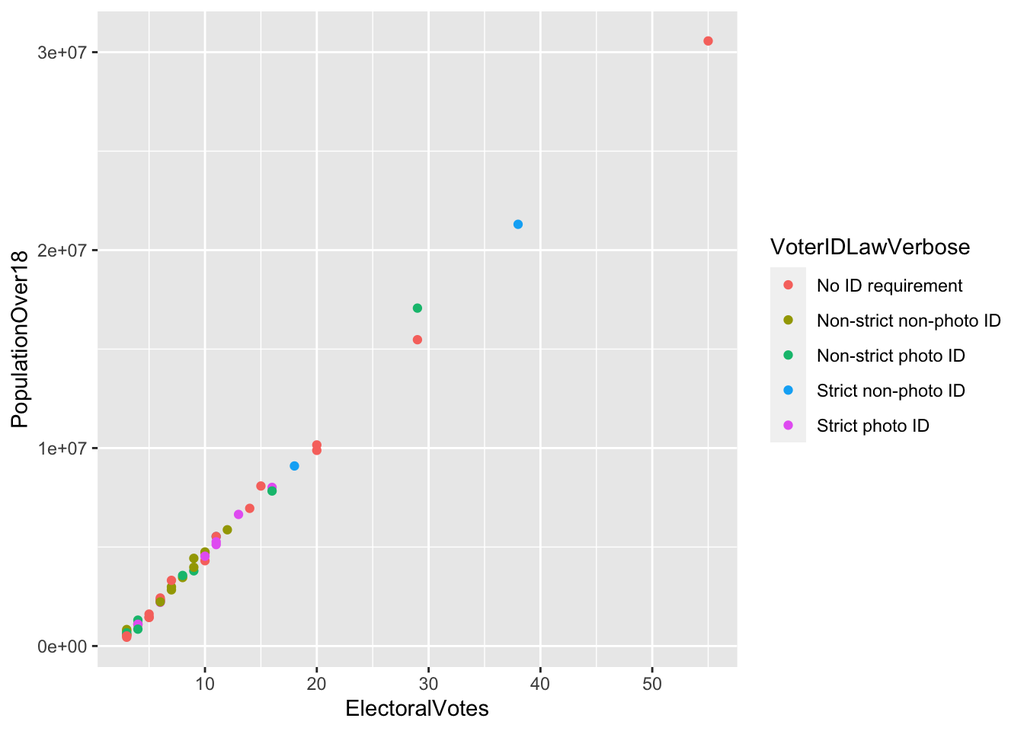

```r
ggplot(stateVoterInfo, mapping = aes(x = ElectoralVotes, y = PopulationOver18, color = VoterIDLawVerbose)) +
  geom_point(alpha = 1)
```

This bar graph shows the number of states that have a certain voter ID law. No ID requirement has by far the most number of states. Surprisingly Strict photo ID has more than double of Strict non-photo ID.

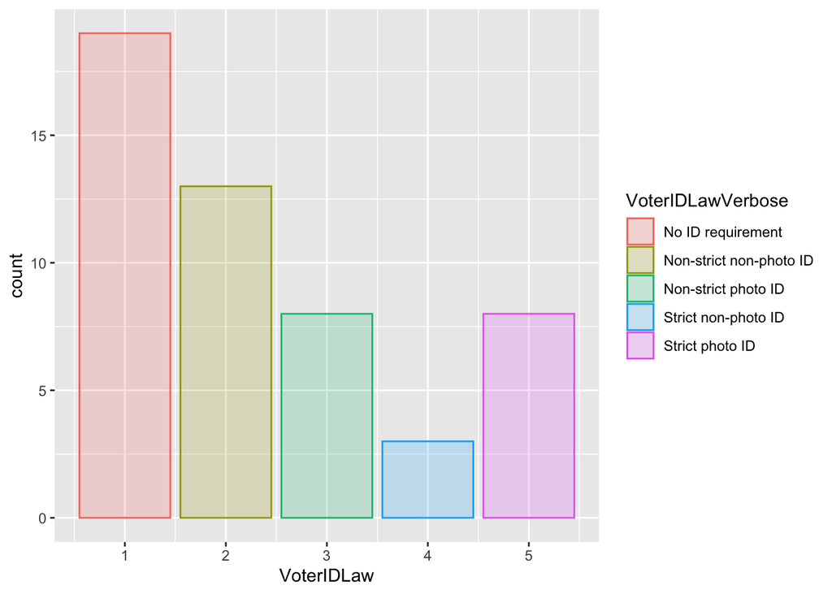

```r
ggplot(stateInfo, mapping = aes(x = VoterIDLaw, color = VoterIDLawVerbose)) +
  geom_bar(mapping = aes(fill = VoterIDLawVerbose), alpha = 0.2)
```

This graph is similar to the previous graph, except for one change. The voter ID laws are color coded for which states allow for party registration. This is a variable in the stateInfo table. There is nothing too jaw dropping here, but it is clear that there are more states that allow party registration than not.

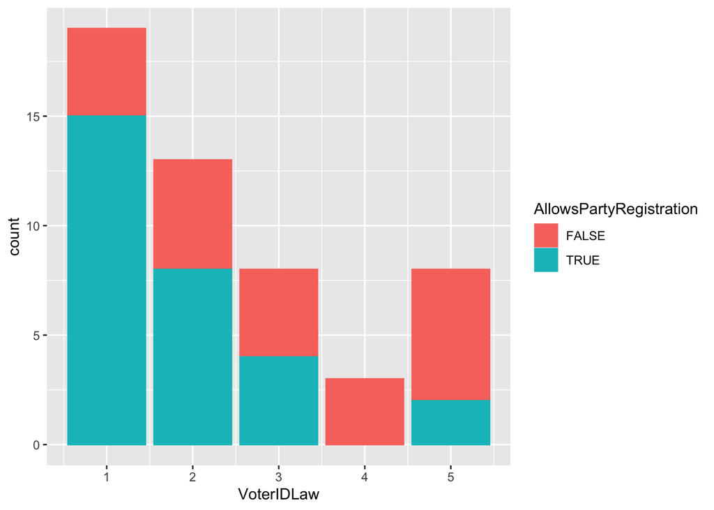

```r
ggplot(stateInfo, mapping = aes(x = VoterIDLaw, color = AllowsPartyRegistration)) +
  geom_bar(aes(fill = AllowsPartyRegistration))
```

## Validation

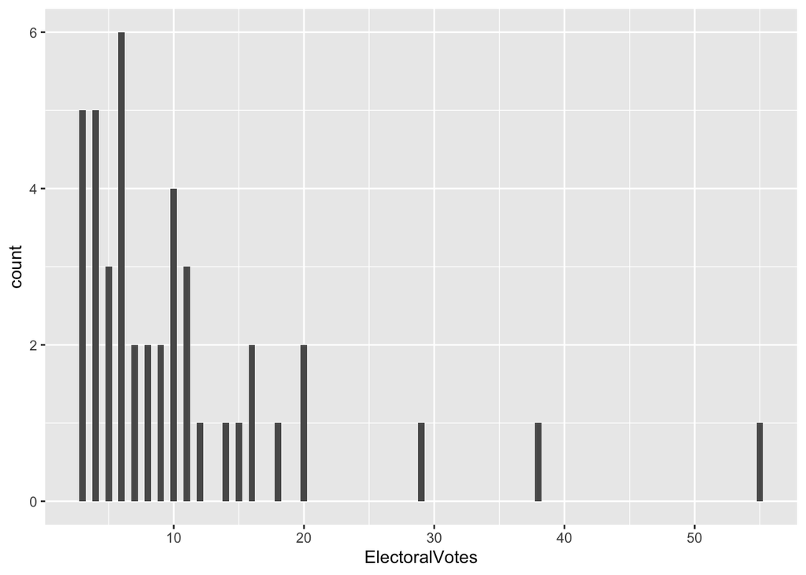

```r
set.seed(1234)
rest_rows <- as.vector(createDataPartition(turnout1216$turnoutPercent2016, p = 0.8, list = FALSE))
test <- turnout1216[-rest_rows, ]
rest <- turnout1216[rest_rows, ]

ggplot(data = rest) +
  geom_histogram(mapping = aes(x = ElectoralVotes), binwidth = .5)
```

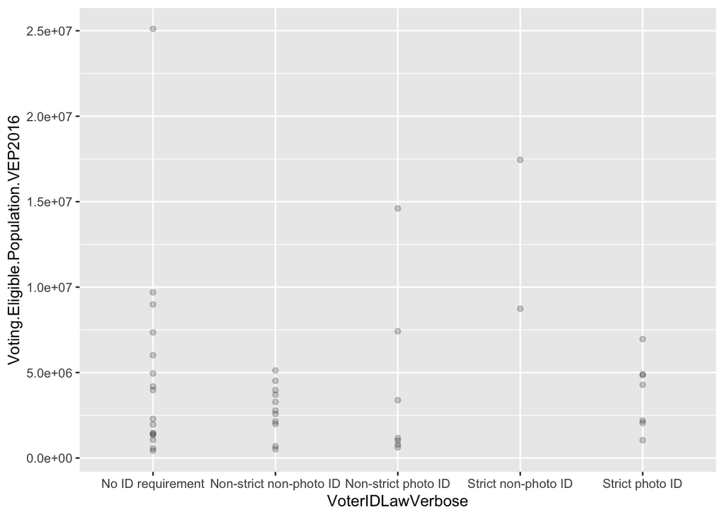

```r
ggplot(data = rest) +
  geom_point(mapping = aes(x = VoterIDLawVerbose, y = Voting.Eligible.Population.VEP2016), alpha = 0.2)
```

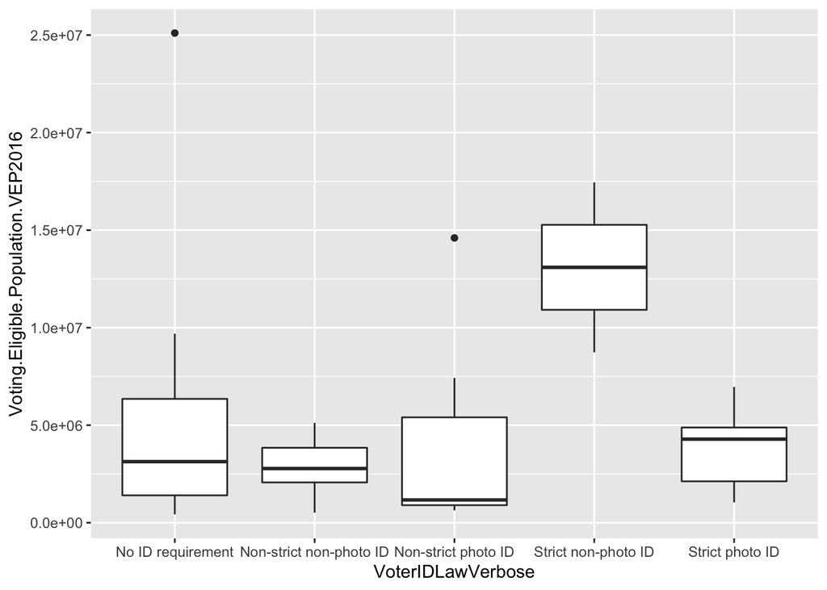

```r
ggplot(data = rest) +
  geom_boxplot(mapping = aes(x = VoterIDLawVerbose, y = Voting.Eligible.Population.VEP2016))
```

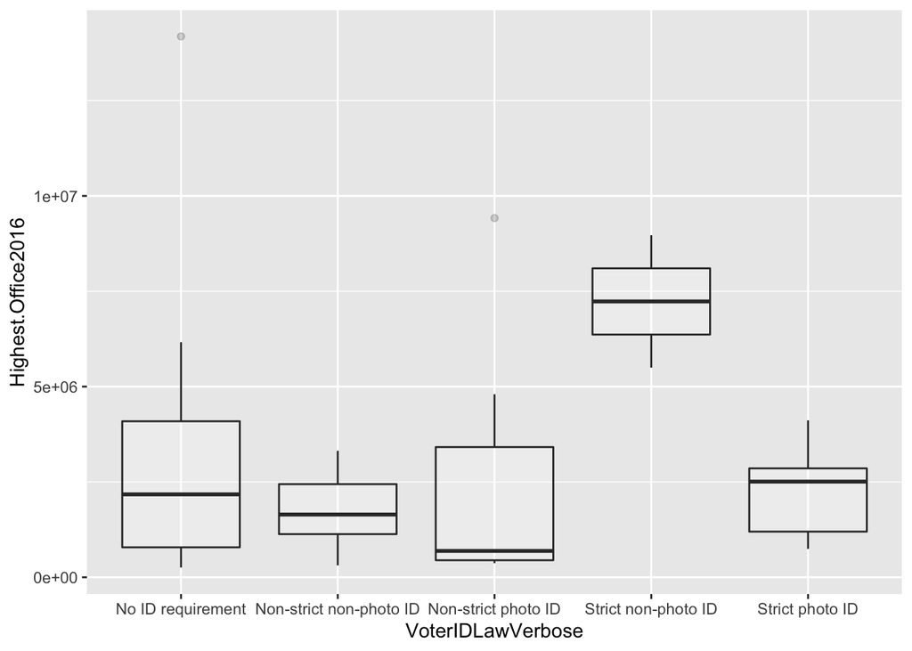

```r
ggplot(data = rest) +
  geom_boxplot(mapping = aes(x = VoterIDLawVerbose, y = Highest.Office2016), alpha = 0.2)
```

```r
train_rows <- as.vector(createDataPartition(rest$turnoutPercent2016, p = 0.75, list = FALSE))

validate <- rest[-train_rows, ]
train <- rest[train_rows, ]
```

## Training Different Models

#### First Model

```r
model1 <- lm(turnoutPercent2016 ~ Voting.Age.Population.VAP2016 + Total.Ballots.Counted2012 + Voting.Eligible.Population.VEP2012 + VoterIDLawVerbose, data = train)
model1
```

```
##
## Call:
## lm(formula = turnoutPercent2016 ~ Voting.Age.Population.VAP2016 +
##     Total.Ballots.Counted2012 + Voting.Eligible.Population.VEP2012 +
##     VoterIDLawVerbose, data = train)
##
## Coefficients:
##                              (Intercept)
##                                6.238e+01
##            Voting.Age.Population.VAP2016
##                                2.587e-06
##                Total.Ballots.Counted2012
##                                1.999e-05
##       Voting.Eligible.Population.VEP2012
##                               -1.478e-05
## VoterIDLawVerboseNon-strict non-photo ID
##                               -1.850e+00
##     VoterIDLawVerboseNon-strict photo ID
##                               -6.398e+00
##     VoterIDLawVerboseStrict non-photo ID
##                                1.405e+01
##         VoterIDLawVerboseStrict photo ID
##                               -1.071e+00
```

```r
predictions1 <- add_predictions(validate, model1)
head(predictions1)
```

```
##    State     StateName StateAbbr ElectoralVotes AllowsPartyRegistration
## 13    16         Idaho        ID              4                    TRUE
## 14    17      Illinois        IL             20                   FALSE
## 15    18       Indiana        IN             11                   FALSE
## 16    19          Iowa        IA              6                    TRUE
## 22    25 Massachusetts        MA             11                    TRUE
## 32    35    New Mexico        NM              5                    TRUE
##    VoterIDLaw   VoterIDLawVerbose ClosedPrimary VEP.Total.Ballots.Counted2016
## 13          3 Non-strict photo ID         FALSE                        60.90%
## 14          1   No ID requirement         FALSE                        63.10%
## 15          5     Strict photo ID         FALSE                        57.90%
## 16          1   No ID requirement         FALSE                        69.10%
## 22          1   No ID requirement         FALSE                        68.30%
## 32          1   No ID requirement          TRUE                        54.90%
##    VEP.Highest.Office2016 VAP.Highest.Office2016 Total.Ballots.Counted2016
```

[output cut: 48 more lines]

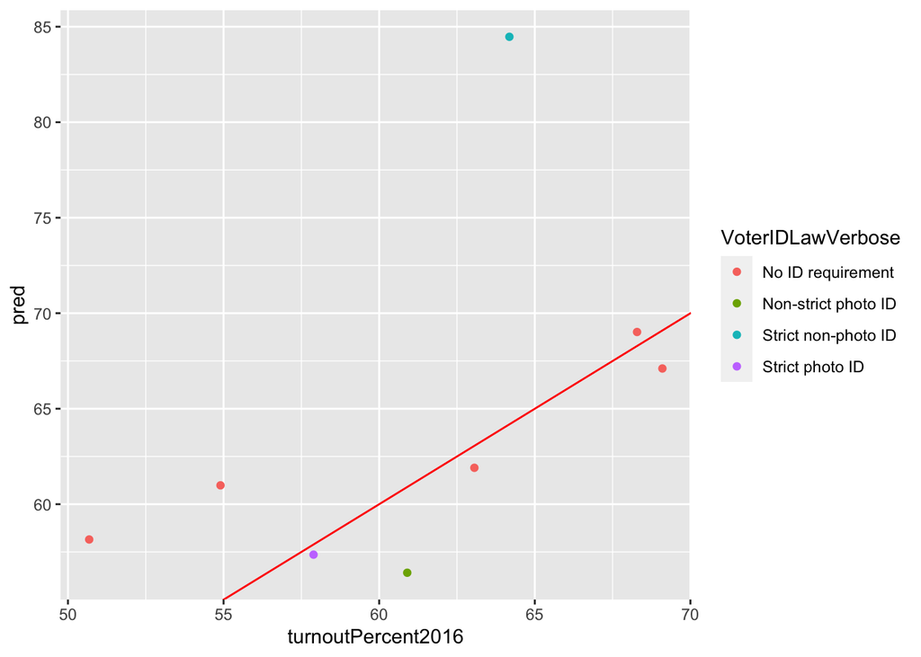

```r
ggplot(data = predictions1, mapping = aes(x = turnoutPercent2016, y = pred, color = VoterIDLawVerbose)) +
  geom_point() +
  geom_abline(intercept = 0, slope = 1, color = "red")
```

```r
R2(predictions1$pred, predictions1$turnoutPercent2016)
```

```
## [1] 0.2867164
```

```r
MAE(predictions1$pred, predictions1$turnoutPercent2016)
```

```
## [1] 5.342912
```

```r
RMSE(predictions1$pred, predictions1$turnoutPercent2016)
```

```
## [1] 8.145064
```

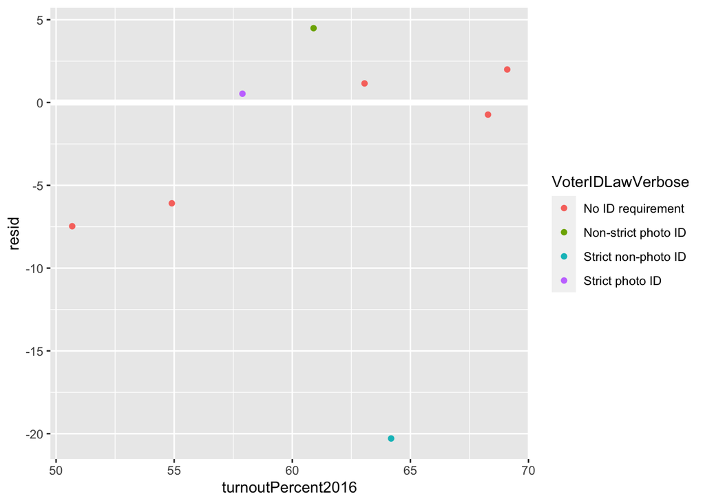

```r
resids1 <- add_residuals(validate, model1)

ggplot(data = resids1, mapping = aes(x = turnoutPercent2016, y = resid, color = VoterIDLawVerbose)) +
  geom_ref_line(h = 0) +
  geom_point()
```

This was my original model in Deliverable #2. The R squared variable is 0.287, this is not as close to one as I would like it to be. The MAE variable is 5.34 and the RMSE variable is 8.15. These are larger than I would like them to be. I am going to add the variable ElecotralVotes to the model to test if the model gets better.

#### Second Model

```r
model2 <- lm(turnoutPercent2016 ~ Voting.Age.Population.VAP2016 + Total.Ballots.Counted2012 + Voting.Eligible.Population.VEP2012 + ElectoralVotes + VoterIDLawVerbose, data = train)
model2
```

```
##
## Call:
## lm(formula = turnoutPercent2016 ~ Voting.Age.Population.VAP2016 +
##     Total.Ballots.Counted2012 + Voting.Eligible.Population.VEP2012 +
##     ElectoralVotes + VoterIDLawVerbose, data = train)
##
## Coefficients:
##                              (Intercept)
##                                5.496e+01
##            Voting.Age.Population.VAP2016
##                               -2.307e-06
##                Total.Ballots.Counted2012
##                                2.228e-05
##       Voting.Eligible.Population.VEP2012
##                               -1.713e-05
##                           ElectoralVotes
##                                3.311e+00
## VoterIDLawVerboseNon-strict non-photo ID
##                               -9.472e-01
##     VoterIDLawVerboseNon-strict photo ID
##                               -5.397e+00
##     VoterIDLawVerboseStrict non-photo ID
##                                1.631e+01
##         VoterIDLawVerboseStrict photo ID
##                               -8.414e-01
```

```r
predictions2 <- add_predictions(validate, model2)
head(predictions2)
```

```
##    State     StateName StateAbbr ElectoralVotes AllowsPartyRegistration
## 13    16         Idaho        ID              4                    TRUE
## 14    17      Illinois        IL             20                   FALSE
## 15    18       Indiana        IN             11                   FALSE
## 16    19          Iowa        IA              6                    TRUE
## 22    25 Massachusetts        MA             11                    TRUE
## 32    35    New Mexico        NM              5                    TRUE
##    VoterIDLaw   VoterIDLawVerbose ClosedPrimary VEP.Total.Ballots.Counted2016
## 13          3 Non-strict photo ID         FALSE                        60.90%
## 14          1   No ID requirement         FALSE                        63.10%
## 15          5     Strict photo ID         FALSE                        57.90%
## 16          1   No ID requirement         FALSE                        69.10%
## 22          1   No ID requirement         FALSE                        68.30%
## 32          1   No ID requirement          TRUE                        54.90%
##    VEP.Highest.Office2016 VAP.Highest.Office2016 Total.Ballots.Counted2016
```

[output cut: 48 more lines]

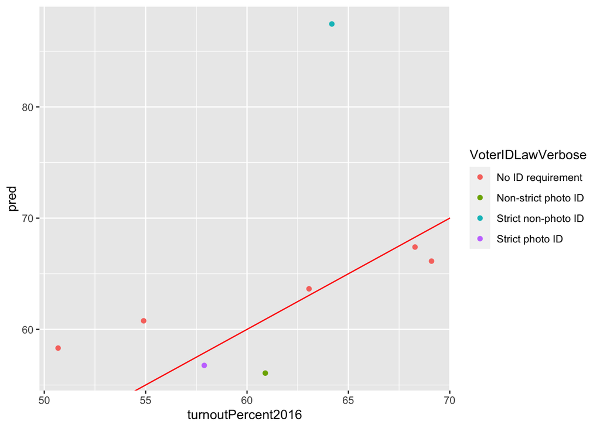

```r
ggplot(data = predictions2, mapping = aes(x = turnoutPercent2016, y = pred, color = VoterIDLawVerbose)) +
  geom_point() +
  geom_abline(intercept = 0, slope = 1, color = "red")
```

```r
R2(predictions2$pred, predictions2$turnoutPercent2016)
```

```
## [1] 0.2280279
```

```r
MAE(predictions2$pred, predictions2$turnoutPercent2016)
```

```
## [1] 5.89652
```

```r
RMSE(predictions2$pred, predictions2$turnoutPercent2016)
```

```
## [1] 9.143253
```

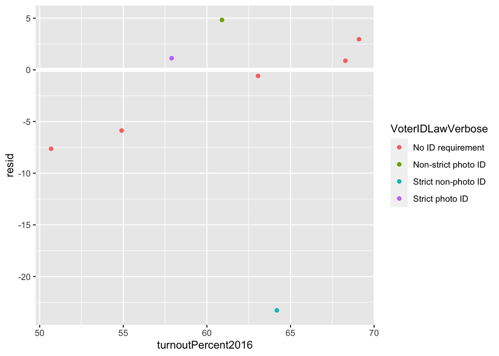

```r
resids2 <- add_residuals(validate, model2)

ggplot(data = resids2, mapping = aes(x = turnoutPercent2016, y = resid, color = VoterIDLawVerbose)) +
  geom_ref_line(h = 0) +
  geom_point()
```

The R squared variable is 0.228, which is smaller than the R Squared variable in the first model. The MAE variable is 5.90 and the RMSE variable is 9.14. These are larger than first model. All of the variables are worse than in the first model. When comparing the residual plots between the two models there is virtually no change. Due to these reasons I decided to keep the first model.

## MY MODEL

I have attempted to add many different variables into this model, I only included two of them that showed the most change, but surprisingly the model does not change. The variables that I have added all have not significantly changed the model or predictions. I wanted to add in demographic data to this model but it was not possible because the demographic data is county related, not state.

Below is the model I have decided to use:

```r
turnout1216Untouched <- turnout1216
mymodel <- lm(turnoutPercent2016 ~ Voting.Age.Population.VAP2016 + Total.Ballots.Counted2012 + Voting.Eligible.Population.VEP2012 + VoterIDLawVerbose, data = rest)
mymodel
```

```
##
## Call:
## lm(formula = turnoutPercent2016 ~ Voting.Age.Population.VAP2016 +
##     Total.Ballots.Counted2012 + Voting.Eligible.Population.VEP2012 +
##     VoterIDLawVerbose, data = rest)
##
## Coefficients:
##                              (Intercept)
##                                6.191e+01
##            Voting.Age.Population.VAP2016
##                                3.825e-06
##                Total.Ballots.Counted2012
##                                1.758e-05
##       Voting.Eligible.Population.VEP2012
##                               -1.480e-05
## VoterIDLawVerboseNon-strict non-photo ID
##                               -1.158e+00
##     VoterIDLawVerboseNon-strict photo ID
##                               -4.896e+00
##     VoterIDLawVerboseStrict non-photo ID
##                                2.642e+00
##         VoterIDLawVerboseStrict photo ID
##                               -1.506e-01
```

```r
mymodel$coefficients
```

```
##                              (Intercept)
##                             6.191080e+01
##            Voting.Age.Population.VAP2016
##                             3.825270e-06
##                Total.Ballots.Counted2012
##                             1.757923e-05
##       Voting.Eligible.Population.VEP2012
##                            -1.479879e-05
## VoterIDLawVerboseNon-strict non-photo ID
##                            -1.158313e+00
##     VoterIDLawVerboseNon-strict photo ID
##                            -4.896188e+00
##     VoterIDLawVerboseStrict non-photo ID
##                             2.642424e+00
##         VoterIDLawVerboseStrict photo ID
##                            -1.505813e-01
```

```r
mypredictions <- add_predictions(rest, mymodel)
head(mypredictions)
```

```
##   State            StateName StateAbbr ElectoralVotes AllowsPartyRegistration
## 4     5             Arkansas        AR              6                   FALSE
## 5     6           California        CA             55                    TRUE
## 6     8             Colorado        CO              9                    TRUE
## 7     9          Connecticut        CT              7                    TRUE
## 8    10             Delaware        DE              3                    TRUE
## 9    11 District of Columbia        DC              3                    TRUE
##   VoterIDLaw       VoterIDLawVerbose ClosedPrimary
## 4          2 Non-strict non-photo ID         FALSE
## 5          1       No ID requirement         FALSE
## 6          2 Non-strict non-photo ID         FALSE
## 7          2 Non-strict non-photo ID         FALSE
## 8          2 Non-strict non-photo ID          TRUE
## 9          2 Non-strict non-photo ID         FALSE
##   VEP.Total.Ballots.Counted2016 VEP.Highest.Office2016 VAP.Highest.Office2016
```

[output cut: 55 more lines]

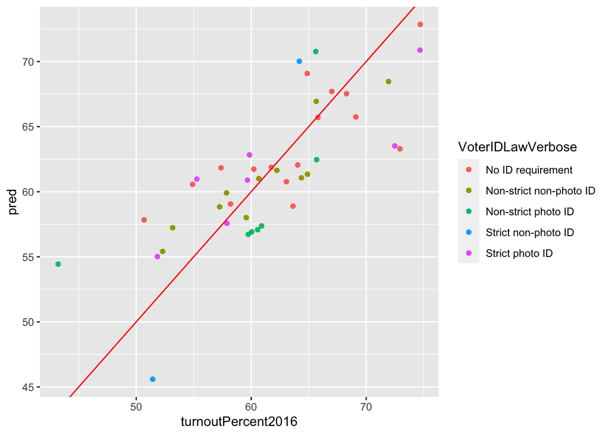

```r
ggplot(data = mypredictions, mapping = aes(x = turnoutPercent2016, y = pred, color = VoterIDLawVerbose)) +
  geom_point() +
  geom_abline(intercept = 0, slope = 1, color = "red")
```

```r
R2(mypredictions$pred, mypredictions$turnoutPercent2016)
```

```
## [1] 0.6078404
```

```r
MAE(mypredictions$pred, mypredictions$turnoutPercent2016)
```

```
## [1] 3.370653
```

```r
RMSE(mypredictions$pred, mypredictions$turnoutPercent2016)
```

```
## [1] 4.204037
```

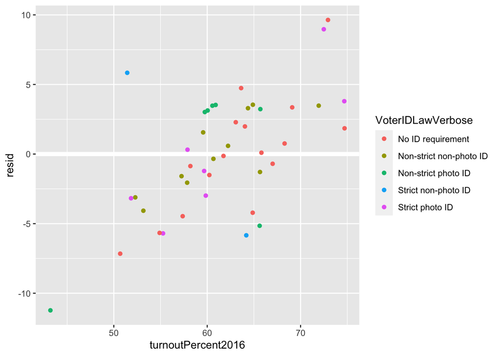

```r
myresids <- add_residuals(rest, mymodel)

ggplot(data = myresids, mapping = aes(x = turnoutPercent2016, y = resid, color = VoterIDLawVerbose)) +
  geom_ref_line(h = 0) +
  geom_point()
```

## TEST

```r
predictions <- add_predictions(test, mymodel)
head(predictions)
```

```
##    State StateName StateAbbr ElectoralVotes AllowsPartyRegistration VoterIDLaw
## 1      1   Alabama        AL              9                   FALSE          3
## 2      2    Alaska        AK              3                    TRUE          2
## 3      4   Arizona        AZ             11                   FALSE          4
## 27    30   Montana        MT              3                   FALSE          2
## 33    36  New York        NY             29                    TRUE          1
## 38    41    Oregon        OR              7                    TRUE          1
##          VoterIDLawVerbose ClosedPrimary VEP.Total.Ballots.Counted2016
## 1      Non-strict photo ID         FALSE                        59.10%
## 2  Non-strict non-photo ID         FALSE                        61.50%
## 3      Strict non-photo ID         FALSE                        56.10%
## 27 Non-strict non-photo ID         FALSE                        64.30%
## 33       No ID requirement          TRUE                        57.20%
## 38       No ID requirement         FALSE                        68.00%
##    VEP.Highest.Office2016 VAP.Highest.Office2016 Total.Ballots.Counted2016
```

[output cut: 48 more lines]

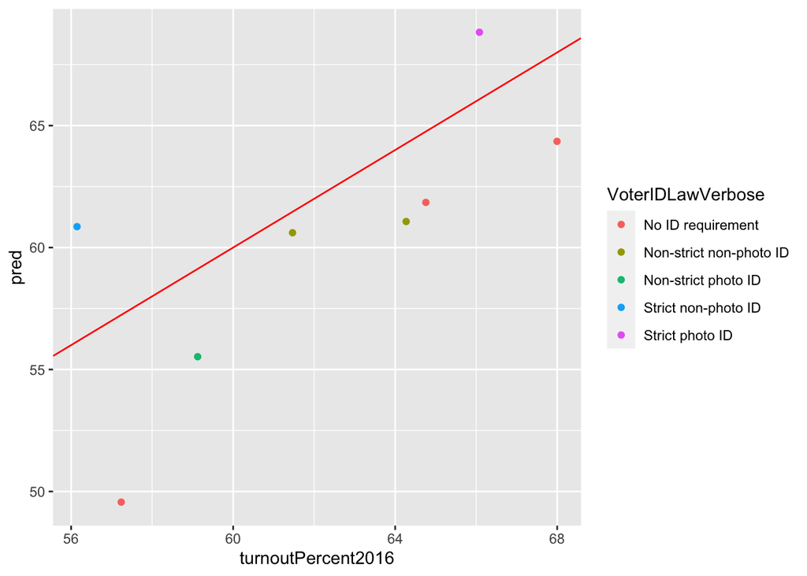

```r
ggplot(data = predictions, mapping = aes(x = turnoutPercent2016, y = pred, color = VoterIDLawVerbose)) +
  geom_point() +
  geom_abline(intercept = 0, slope = 1, color = "red")
```

```r
R2(predictions$pred, predictions$turnoutPercent2016)
```

```
## [1] 0.5310544
```

```r
MAE(predictions$pred, predictions$turnoutPercent2016)
```

```
## [1] 3.667748
```

```r
RMSE(predictions$pred, predictions$turnoutPercent2016)
```

```
## [1] 4.097073
```

```r
resids <- add_residuals(test, mymodel)
head(resids)
```

```
##    State StateName StateAbbr ElectoralVotes AllowsPartyRegistration VoterIDLaw
## 1      1   Alabama        AL              9                   FALSE          3
## 2      2    Alaska        AK              3                    TRUE          2
## 3      4   Arizona        AZ             11                   FALSE          4
## 27    30   Montana        MT              3                   FALSE          2
## 33    36  New York        NY             29                    TRUE          1
## 38    41    Oregon        OR              7                    TRUE          1
##          VoterIDLawVerbose ClosedPrimary VEP.Total.Ballots.Counted2016
## 1      Non-strict photo ID         FALSE                        59.10%
## 2  Non-strict non-photo ID         FALSE                        61.50%
## 3      Strict non-photo ID         FALSE                        56.10%
## 27 Non-strict non-photo ID         FALSE                        64.30%
## 33       No ID requirement          TRUE                        57.20%
## 38       No ID requirement         FALSE                        68.00%
##    VEP.Highest.Office2016 VAP.Highest.Office2016 Total.Ballots.Counted2016
```

[output cut: 48 more lines]

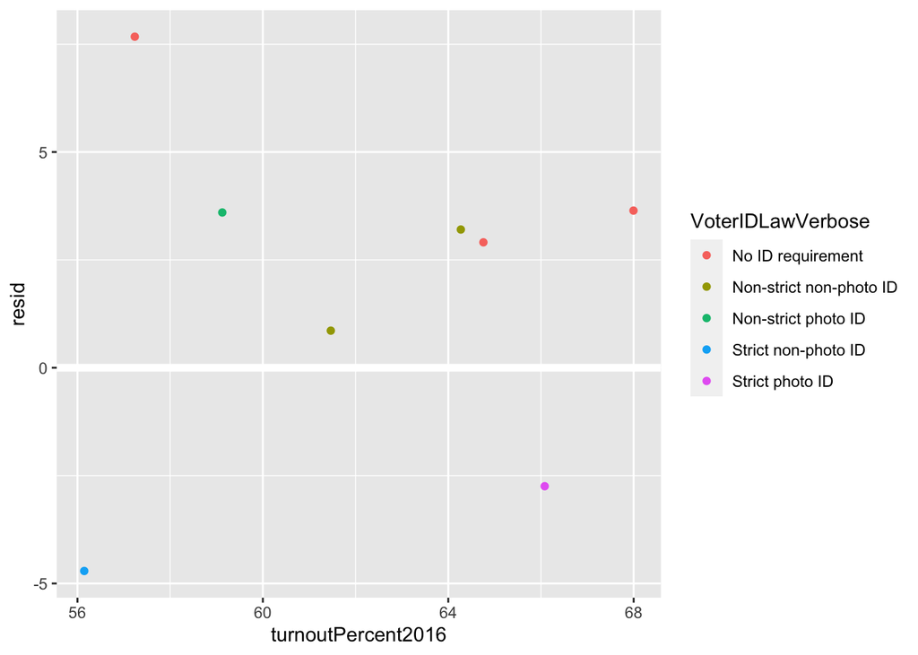

```r
ggplot(data = resids, mapping = aes(x = turnoutPercent2016, y = resid, color = VoterIDLawVerbose)) +
  geom_ref_line(h = 0) +
  geom_point()
```

## Old Models

This was my original model, but this does not work well. The first issue is that the variable VoterIDLaw is categorical, so it is hard to work with all together. I split up the tibble into five for each category (I have not included these models in the report). Another issue is that this linear model is using the voter law of that state to predict the turnout percent per state. This is far too simple. My model below uses numerous variables to predict voter turnout percent per state.

```r
model <- lm(turnoutPercent2016 ~ VoterIDLaw, data = stateVoterTurnout2016)
model
```

```
##
## Call:
## lm(formula = turnoutPercent2016 ~ VoterIDLaw, data = stateVoterTurnout2016)
##
## Coefficients:
## (Intercept)   VoterIDLaw
##     63.2297      -0.6456
```

```r
model$coefficients
```

```
## (Intercept)  VoterIDLaw
##  63.2296852  -0.6456405
```

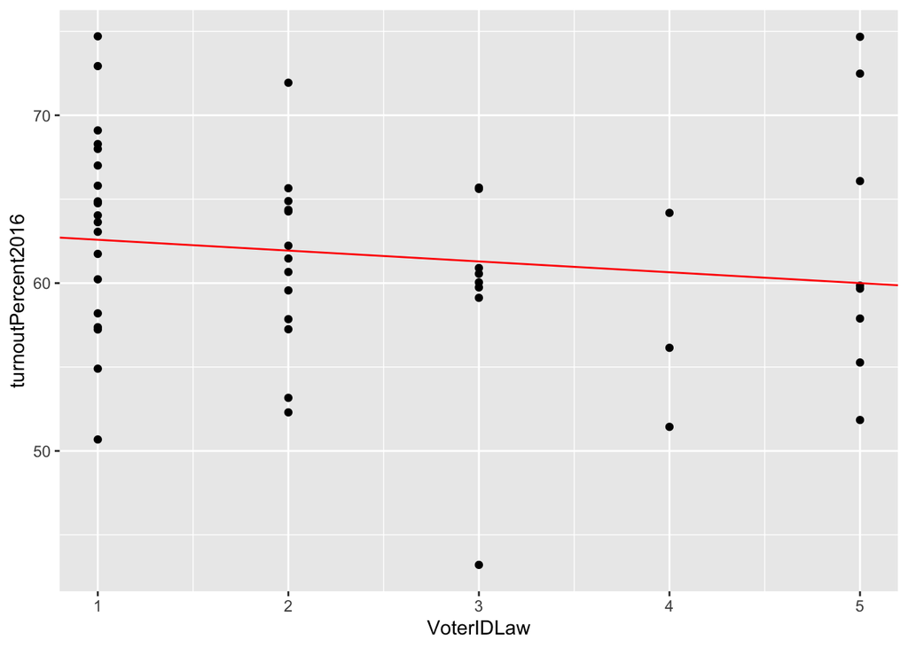

```r
ggplot(data = stateVoterTurnout2016, mapping = aes(x = VoterIDLaw, y = turnoutPercent2016)) +
  geom_point() +
  geom_abline(intercept = model$coefficients[1], slope = model$coefficients[2], color = "red")
```

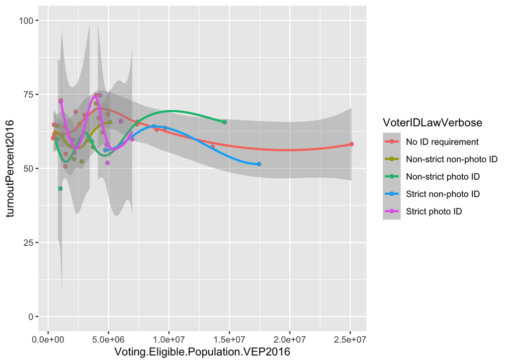

```r
ggplot(stateVoterTurnout2016, mapping = aes(x = Voting.Eligible.Population.VEP2016, y = turnoutPercent2016, color = VoterIDLawVerbose)) +
  geom_point(alpha = 1) +
  geom_smooth() +
  ylim(0,100)
```

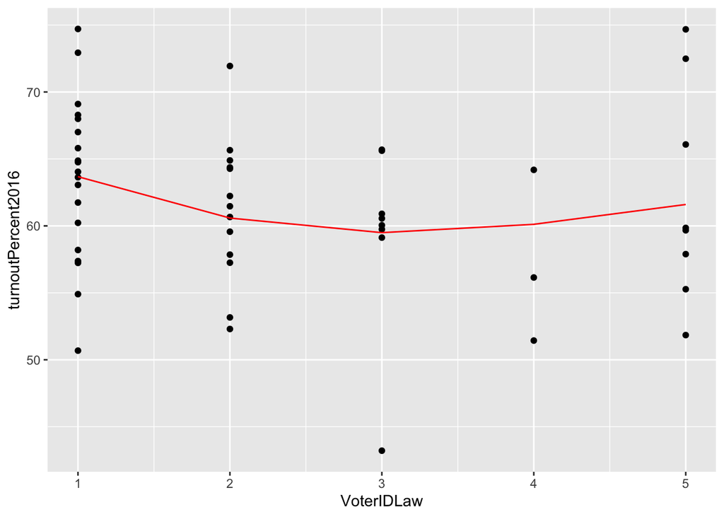

```r
model3 <- lm(turnoutPercent2016 ~ ns(VoterIDLaw, 2), data = stateVoterTurnout2016)

grid3 <- data_grid(stateVoterTurnout2016, VoterIDLaw) %>%
  add_predictions(model3)

data <- add_residuals(stateVoterTurnout2016, model3)

ggplot(data = data, mapping = aes(x = VoterIDLaw)) +
  geom_point(mapping = aes(y = turnoutPercent2016)) +
  geom_line(mapping = aes(y = pred), data = grid3, color = "red")
```

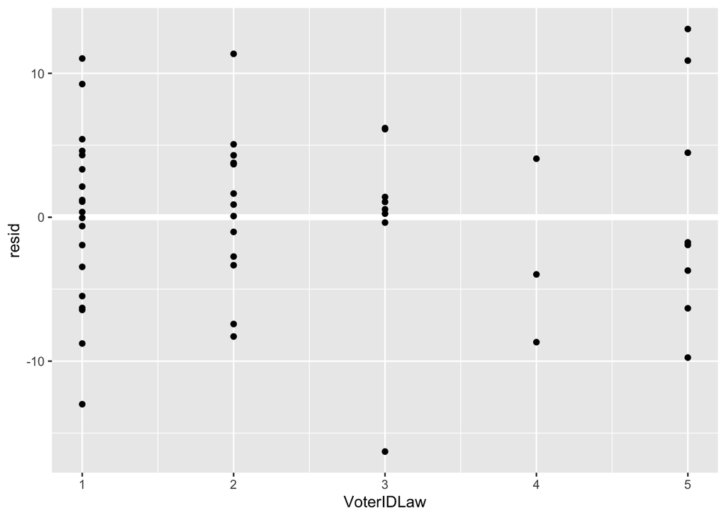

```r
ggplot(data = data, mapping = aes(x = VoterIDLaw, y = resid)) +
  geom_ref_line(h = 0) +
  geom_point()
```

```r
one <- turnout1216Untouched %>%
  filter(VoterIDLaw == 1)
two <- turnout1216Untouched %>%
  filter(VoterIDLaw == 2)
three <- turnout1216Untouched %>%
  filter(VoterIDLaw == 3)
four <- turnout1216Untouched %>%
  filter(VoterIDLaw == 4)
five <- turnout1216Untouched %>%
  filter(VoterIDLaw == 5)
```

## No ID Requirement

```r
model1 <- lm(turnoutPercent2016 ~ Voting.Age.Population.VAP2016 + Total.Ballots.Counted2012 + Voting.Eligible.Population.VEP2012, data = one)
model1
```

```
##
## Call:
## lm(formula = turnoutPercent2016 ~ Voting.Age.Population.VAP2016 +
##     Total.Ballots.Counted2012 + Voting.Eligible.Population.VEP2012,
##     data = one)
##
## Coefficients:
##                        (Intercept)       Voting.Age.Population.VAP2016
##                          6.134e+01                           1.039e-06
##          Total.Ballots.Counted2012  Voting.Eligible.Population.VEP2012
##                          1.627e-05                          -1.052e-05
```

```r
model1$coefficients
```

```
##                        (Intercept)      Voting.Age.Population.VAP2016
##                       6.133668e+01                       1.039367e-06
##          Total.Ballots.Counted2012 Voting.Eligible.Population.VEP2012
##                       1.626842e-05                      -1.051568e-05
```

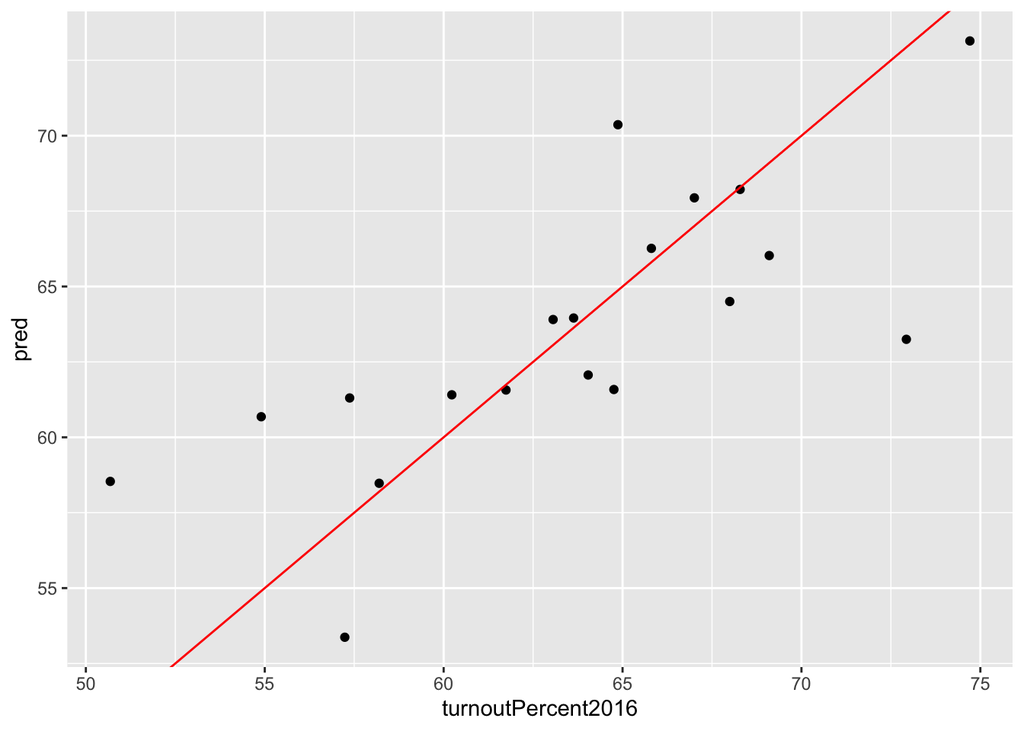

```r
one <- add_predictions(one, model1)
ggplot(data = one, mapping = aes(x = turnoutPercent2016, y = pred)) +
  geom_point() +
  geom_abline(intercept = 0, slope = 1, color = "red")
```

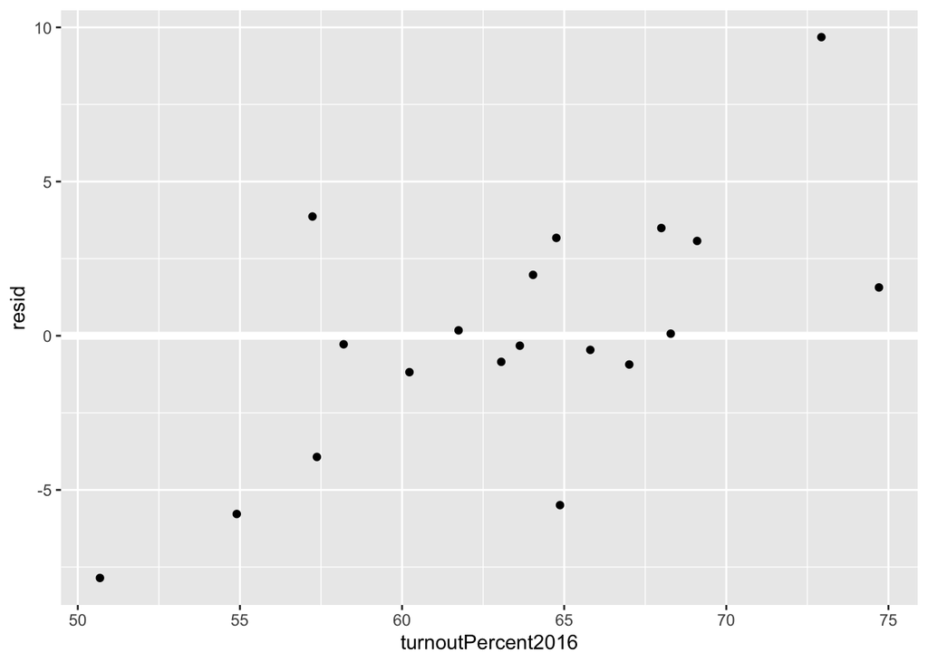

```r
one <- add_residuals(one, model1)
ggplot(data = one, mapping = aes(x = turnoutPercent2016, y = resid)) +
  geom_ref_line(h = 0) +
  geom_point()
```

### Non-strict non-photo ID

```r
model2 <- lm(turnoutPercent2016 ~ Voting.Age.Population.VAP2016 + Total.Ballots.Counted2012 + Voting.Eligible.Population.VEP2012, data = two)
model2
```

```
##
## Call:
## lm(formula = turnoutPercent2016 ~ Voting.Age.Population.VAP2016 +
##     Total.Ballots.Counted2012 + Voting.Eligible.Population.VEP2012,
##     data = two)
##
## Coefficients:
##                        (Intercept)       Voting.Age.Population.VAP2016
##                          6.283e+01                          -6.538e-06
##          Total.Ballots.Counted2012  Voting.Eligible.Population.VEP2012
##                          3.240e-05                          -1.288e-05
```

```r
model2$coefficients
```

```
##                        (Intercept)      Voting.Age.Population.VAP2016
##                       6.283066e+01                      -6.538408e-06
##          Total.Ballots.Counted2012 Voting.Eligible.Population.VEP2012
##                       3.240273e-05                      -1.288309e-05
```

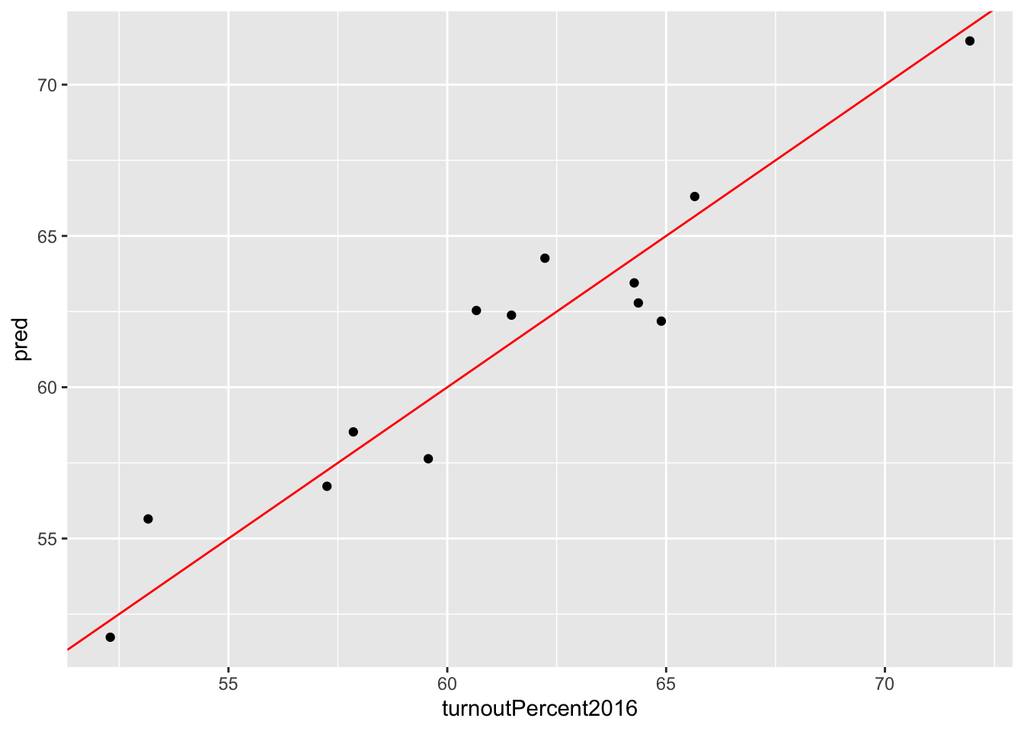

```r
two <- add_predictions(two, model2)
ggplot(data = two, mapping = aes(x = turnoutPercent2016, y = pred)) +
  geom_point() +
  geom_abline(intercept = 0, slope = 1, color = "red")
```

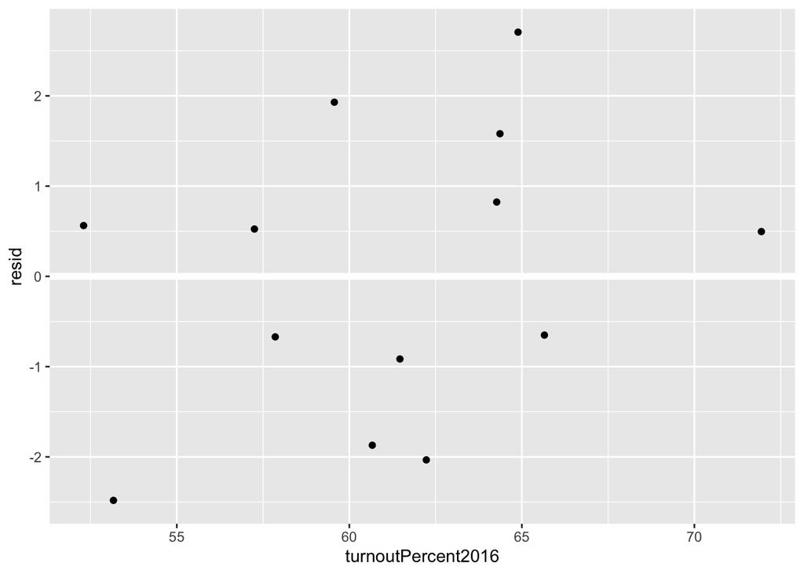

```r
two <- add_residuals(two, model2)
ggplot(data = two, mapping = aes(x = turnoutPercent2016, y = resid)) +
  geom_ref_line(h = 0) +
  geom_point()
```

### Non-strict photo ID

```r
model3 <- lm(turnoutPercent2016 ~ Voting.Age.Population.VAP2016 + Total.Ballots.Counted2012 + Voting.Eligible.Population.VEP2012, data = three)
model3
```

```
##
## Call:
## lm(formula = turnoutPercent2016 ~ Voting.Age.Population.VAP2016 +
##     Total.Ballots.Counted2012 + Voting.Eligible.Population.VEP2012,
##     data = three)
##
## Coefficients:
##                        (Intercept)       Voting.Age.Population.VAP2016
##                          5.966e+01                           3.148e-07
##          Total.Ballots.Counted2012  Voting.Eligible.Population.VEP2012
##                          4.187e-05                          -2.644e-05
```

```r
model3$coefficients
```

```
##                        (Intercept)      Voting.Age.Population.VAP2016
##                       5.966277e+01                       3.147668e-07
##          Total.Ballots.Counted2012 Voting.Eligible.Population.VEP2012
##                       4.187371e-05                      -2.644483e-05
```

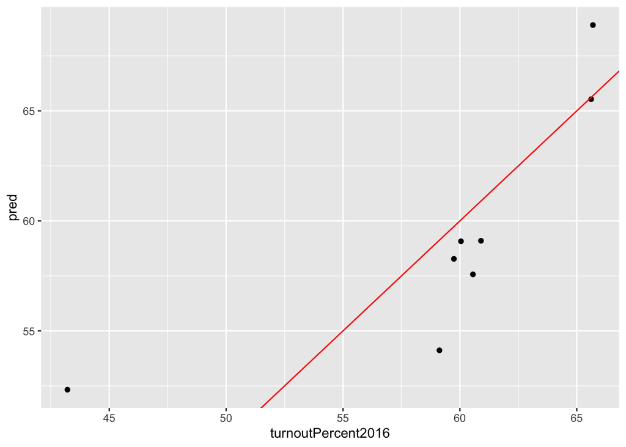

```r
three <- add_predictions(three, model3)
ggplot(data = three, mapping = aes(x = turnoutPercent2016, y = pred)) +
  geom_point() +
  geom_abline(intercept = 0, slope = 1, color = "red")
```

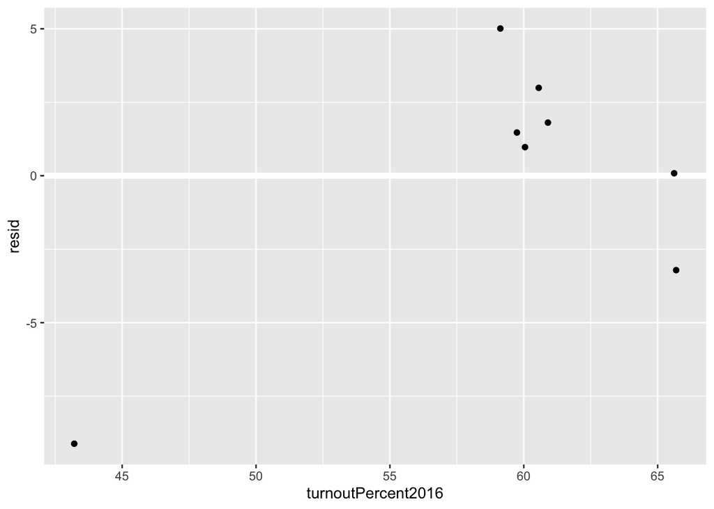

```r
three <- add_residuals(three, model3)
ggplot(data = three, mapping = aes(x = turnoutPercent2016, y = resid)) +
  geom_ref_line(h = 0) +
  geom_point()
```

### Strict non-photo ID

```r
model4 <- lm(turnoutPercent2016 ~ Voting.Age.Population.VAP2016 + Total.Ballots.Counted2012 + Voting.Eligible.Population.VEP2012, data = four)
model4
```

```
##
## Call:
## lm(formula = turnoutPercent2016 ~ Voting.Age.Population.VAP2016 +
##     Total.Ballots.Counted2012 + Voting.Eligible.Population.VEP2012,
##     data = four)
##
## Coefficients:
##                        (Intercept)       Voting.Age.Population.VAP2016
##                          5.612e+01                          -2.045e-06
##          Total.Ballots.Counted2012  Voting.Eligible.Population.VEP2012
##                          4.702e-06                                  NA
```

```r
model4$coefficients
```

```
##                        (Intercept)      Voting.Age.Population.VAP2016
##                       5.612283e+01                      -2.044885e-06
##          Total.Ballots.Counted2012 Voting.Eligible.Population.VEP2012
##                       4.701617e-06                                 NA
```

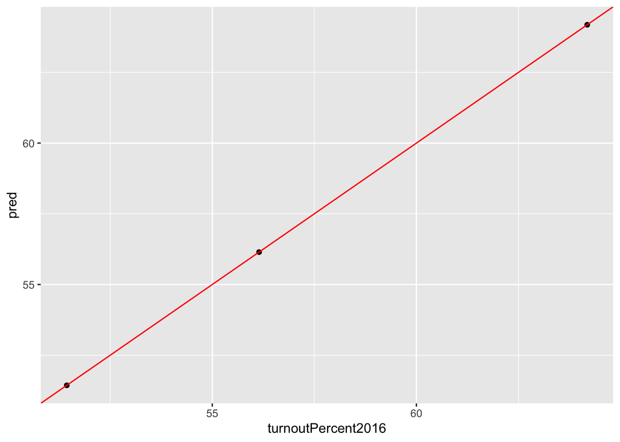

```r
four <- add_predictions(four, model4)
ggplot(data = four, mapping = aes(x = turnoutPercent2016, y = pred)) +
  geom_point() +
  geom_abline(intercept = 0, slope = 1, color = "red")
```

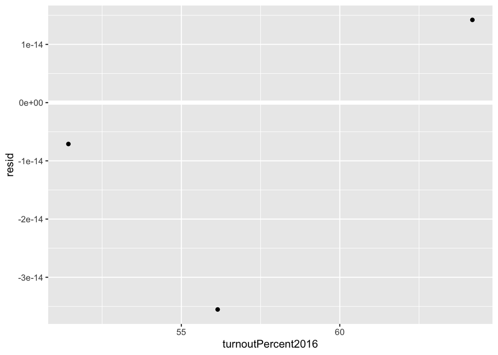

```r
four <- add_residuals(four, model4)
ggplot(data = four, mapping = aes(x = turnoutPercent2016, y = resid)) +
  geom_ref_line(h = 0) +
  geom_point()
```

### Strict photo ID

```r
model5 <- lm(turnoutPercent2016 ~ Voting.Age.Population.VAP2016 + Total.Ballots.Counted2012 + Voting.Eligible.Population.VEP2012, data = five)
model5
```

```
##
## Call:
## lm(formula = turnoutPercent2016 ~ Voting.Age.Population.VAP2016 +
##     Total.Ballots.Counted2012 + Voting.Eligible.Population.VEP2012,
##     data = five)
##
## Coefficients:
##                        (Intercept)       Voting.Age.Population.VAP2016
##                          6.530e+01                           4.033e-06
##          Total.Ballots.Counted2012  Voting.Eligible.Population.VEP2012
##                          2.343e-05                          -1.961e-05
```

```r
model5$coefficients
```

```
##                        (Intercept)      Voting.Age.Population.VAP2016
##                       6.529797e+01                       4.032541e-06
##          Total.Ballots.Counted2012 Voting.Eligible.Population.VEP2012
##                       2.343006e-05                      -1.960508e-05
```

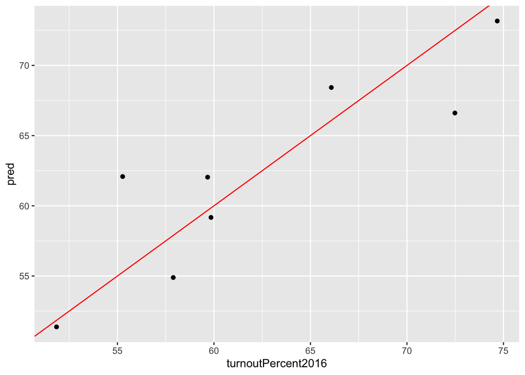

```r
five <- add_predictions(five, model5)
ggplot(data = five, mapping = aes(x = turnoutPercent2016, y = pred)) +
  geom_point() +
  geom_abline(intercept = 0, slope = 1, color = "red")
```

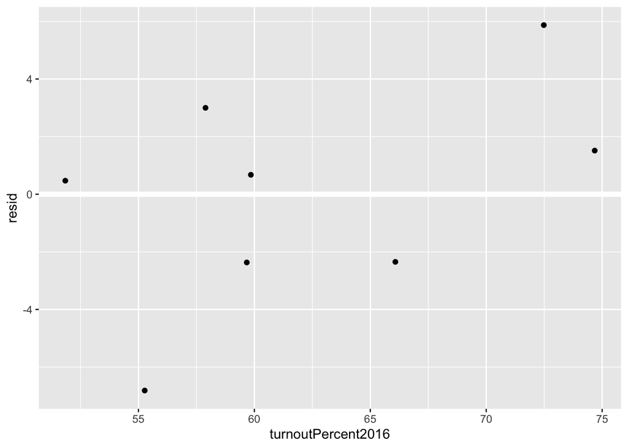

```r
five <- add_residuals(five, model5)
ggplot(data = five, mapping = aes(x = turnoutPercent2016, y = resid)) +
  geom_ref_line(h = 0) +
  geom_point()
```

All of these models are not extremely accurate. It looks like the variables that have been chosen are not the only direct causation to voter turnout. This does not mean that they do not play a factor. These models are not incorrect, they are just not telling the whole picture. There could be other factors like demographics per state or the friction of the political climate per presidential election.

## Summary

In conclusion, it is not possible to determine a state’s voter turnout based on their voter ID law. There are far too many factors that contribute to voter turnout in a presidential election for a given year, and many of them could not be included in my model. Some of these are the demographic of the state, the political climate that year, the satisfaction or dissatisfaction with the current president, and people like Stacy Abrams who put in extra work to get people registered to vote. If there was more data then I could have looked at the relationship between the strictness of the voter ID law and voter turnout per state, but I was unable to do that given that I only have 50 data points spread across 5 types of ID laws. However, it is a very interesting topic and one that is very relevant today. The voter turnout in the 2020 election was immense, and that is something that cannot be explained by which state had which type of voter ID law.